# Aula Introdução ao Python Concluida

### **Aula de Introdução - Python em Econometria**

##### Prof Daniel Uhr e Sérgio Daneris

**A presente aula tem como objetivo capacitar os alunos para o entendimento e a utilização da análise de dados através da linguagem de programação Python**

##### *Visual Studio Code*

O Visual Studio Code é um ambiente de desenvolvimento flexível e personalizável. Com suas extensões, suporta Python, uma linguagem popular para análise de dados.

Usando bibliotecas como Pandas e Matplotlib, os desenvolvedores podem realizar análises e visualizações de dados de forma eficiente e poderosa, tornando o processo mais produtivo.

**Extensões:**

- Jupyter Notebook
- Python
- MarkDown
- Github Copilot
- PowerShell
- R

##### *Github - Acesso a pacote de dados.*

GitHub é uma plataforma de desenvolvimento colaborativo que utiliza o sistema de controle de versão Git. A plataforma oferece um ambiente centralizado para que desenvolvedores compartilhem e colaborem em projetos de software. Os repositórios no GitHub são espaços dedicados para armazenar conjuntos de dados e outros arquivos, permitindo que pesquisadores e desenvolvedores compartilhem essas informações de forma acessível ao público. Esses repositórios facilitam o download e o uso desses dados por outros usuários, promovendo a colaboração e a inovação na comunidade.

**Bibliotecas necessárias para análise de dados:**

- Pandas:

Função: Manipulação e análise. Pode ser utilizado para limpeza e preparação, análise exploratória e transformações complexas em conjuntos de dados.

comando: pip install pandas

- Numpy:

Função: Computação numérica eficiente. Pode ser utilizado para operações matemáticas em larga escala, manipulação eficiente de grandes conjuntos de dados numéricos.

comando: pip install numpy

- Matplotib:

Função: Criação de gráficos 2D. Pode ser utilizado para visualização de dados básico, criação de gráficos personalizados para análises específicas.

comando: pip install matplotib

- StatsModels:

Função: Estimativa e interpretação de modelos estatísticos. Pode ser utilizado para modelagem estatística, análise de dados para pesquisas científicas e acadêmicas.

comando: pip install statsmodels

- Linearmodels:

Função: É usada para analisar e estimar modelos estatísticos lineares. Ela facilita a realização de regressões com diferentes configurações, como erros padrão robustos e efeitos fixos/aleatórios.

comandos: pip instal linearmodels

- Seaborn:

Função: Visualização estatística atraente. Pode ser utilizado para exploração visual de relacionamentos em dados complexos, criação de gráficos estatísticos detalhados.

comando: pip install seaborn

- Scipy:

Função: Extensões de funcionalidades numéricas. Pode ser utilizado para análises estatísticas avançadas, modelagem matemática e científica.

comando: pip install scipy

**Prática:**

```python
# Análise de Dados
# 1°) Vamos importar a biblioteca pandas
# 2°) Vamos acessar o banco de dados através de duas maneiras: Baixando direto de um servidor da web (Exemplo: Github) ou através de um diretório do próprio usuário
# 3°) Visualizar as primeiras colunas com print (dados.head)
# 4°) Quando for baixar pelo github colocar (https://raw.githubusercontent.com) pois quando coloca apenas github.com o python não localiza o arquivo.

import pandas as pd

#informe o URL do arquivo
url = 'https://raw.githubusercontent.com/sergiodaneris/Dados-Aula/main/cattaneo2.csv'

# Usei o dadosgit para nomear a base baixada pela internet
dadosgit = pd.read_csv(url)

# Exibindo as primeiras linhas do DataFrame
print(dadosgit.head())
```

```
   bweight  mmarried  mhisp  fhisp  foreign  alcohol  deadkids  mage  medu  \
0     3459         1      0      0        0        0         0    24    14
1     3260         0      0      0        1        0         0    20    10
2     3572         1      0      0        1        0         0    22     9
3     2948         1      0      0        0        0         0    26    12
4     2410         1      0      0        0        0         0    20    12

   fage  ...  order  msmoke  mbsmoke  mrace  frace  prenatal  birthmonth  \
0    28  ...      2       0        0      1      1         1          12
1     0  ...      3       0        0      0      0         1           7
2    30  ...      3       0        0      1      1         1           3
3    30  ...      2       0        0      1      1         1           1
4    21  ...      1       0        0      1      1         1           3

   lbweight  fbaby  prenatal1
0         0      0          1
1         0      0          1
2         0      0          1
3         0      0          1
4         1      1          1

[5 rows x 23 columns]
```

```python
# Baixar direto de uma pasta do usuário
# Sempre trocar \ por /

dadosusuario = pd.read_csv('C:/Users/sergi/Desktop/Econometria 2/Aulas/cattaneo2.csv')

print (dadosusuario.head)
```

```
<bound method NDFrame.head of       bweight  mmarried  mhisp  fhisp  foreign  alcohol  deadkids  mage  medu  \
0        3459         1      0      0        0        0         0    24    14
1        3260         0      0      0        1        0         0    20    10
2        3572         1      0      0        1        0         0    22     9
3        2948         1      0      0        0        0         0    26    12
4        2410         1      0      0        0        0         0    20    12
...       ...       ...    ...    ...      ...      ...       ...   ...   ...
4637     3317         0      0      0        0        0         0    21    12
4638     3030         1      0      0        0        1         1    30    12
4639     2950         0      0      0        0        0         0    23    12
4640     3969         1      0      0        0        0         0    23    12
4641     3289         1      0      0        0        0         0    22    12

      fage  ...  order  msmoke  mbsmoke  mrace  frace  prenatal  birthmonth  \
0       28  ...      2       0        0      1      1         1          12
```

[output cut: 25 more lines]

##### **Vamos análisar cada váriavel do banco de dados**

- bweight: Peso do bebê ao nascer.
- mmarried: Estado civil da mãe (1 - Casada, 0 - Não casada).
- mhisp: Mãe de origem hispânica (1 - Sim, 0 - Não).
- fhisp: Pai de origem hispânica (1 - Sim, 0 - Não).
- foreign: País de origem (1 - Estrangeiro, 0 - Não estrangeiro).
- alcohol: Consumo de álcool durante a gravidez (1 - Sim, 0 - Não).
- deadkids: Número de filhos mortos anteriormente.
- mage: Idade da mãe.
- medu: Educação da mãe (anos de escolaridade).
- fage: Idade do pai.
- fedu: Educação do pai (anos de escolaridade).
- mblacks: Mãe de origem afro-americana (1 - Sim, 0 - Não).
- fblacks: Pai de origem afro-americana (1 - Sim, 0 - Não).
- mfirst: Gravidez da mãe (1 - Primeira gravidez, 0 - Não é a primeira gravidez).
- parity: Número de filhos já nascidos.
- order: Ordem do nascimento do bebê.
- msmoke: Mãe fumante durante a gravidez (categorizado).
- mbsmoke: Mãe fumante antes da gravidez (categorizado).
- mrace: Raça da mãe (1 - Branca, 0 - Não branca).
- frace: Raça do pai (1 - Branca, 0 - Não branca).
- prenatal: Cuidados pré-natais (1 - Sim, 2 - Não, 3 - Insuficiente).
- birthmonth: Mês do nascimento do bebê.
- lbweight: Peso do bebê ao nascer em categorias (1 - Baixo peso, 0 - Não baixo peso).
- fbaby: Pai do bebê (1 - Sim, 0 - Não).
- prenatal1: Cuidados pré-natais (1 - Sim, 0 - Não).

```python
# Criando uma váriavel dentro do dataframe
# Por exemplo uma váriavel  de risco de Baixo Peso ao Nascer
# Essa variável poderia ser criada combinando algumas das variáveis existentes, como o peso da criança ao nascer (bwghtlbs), a educação da mãe (motheduc) e o nível de escolaridade do pai (fatheduc).
# 5.5 é o peso ao nascer considerado baixo para recem nascido
# 12 é o numero minimo de anos de escolaridade

# Criando a variável que indica o risco de Baixo Peso ao Nascer (BPN)
dadosusuario["risco_bpn"] = (dadosusuario["bweight"] < 5.5) | (dadosusuario["medu"] < 12) | (dadosusuario["fedu"] < 12)

# Imprimindo a variável
print(dadosusuario["risco_bpn"].head())
```

```
0    False
1     True
2     True
3    False
4    False
Name: risco_bpn, dtype: bool
```

O resultado é uma nova coluna no DataFrame dadosusuario chamada "risco_bnp", onde cada entrada é um valor booleano indicando se o respectivo caso possui ou não risco de baixo peso ao nascer.

```python
# Agora vamos calcular todas as estatisticas descritivas do conjunto de dados
# Média, Mediana, Desvio Padrão do peso ao nascer das crianças

# Exibindo as estatísticas descritivas
print(dadosusuario["bweight"].describe())
```

```
count    4642.000000
mean     3361.679879
std       578.819623
min       340.000000
25%      3033.000000
50%      3390.000000
75%      3725.000000
max      5500.000000
Name: bweight, dtype: float64
```

- Count: Este conjunto de dados possui 4.642 observações.
- Mean: A média do peso ao nascer das crianças é de aproximadamente 3.361,68 gramas.
- Std: O desvio padrão do peso ao nascer é de aproximadamente 578,82 gramas, indicando a dispersão dos dados em torno da média.
- Min: O peso mínimo ao nascer registrado é de 340 gramas.
- 25%: 25% das crianças têm um peso ao nascer de 3.033 gramas ou menos.
- 50% (Mediana): A mediana do peso ao nascer é de 3.390 gramas, dividindo o conjunto de dados ao meio.
- 75%: 75% das crianças têm um peso ao nascer de 3.725 gramas ou menos.
- Max: O peso máximo ao nascer registrado é de 5.500 gramas.

```python
# Calculando a variância

var = dadosusuario["bweight"].var()

print(var)
```

```
335032.156065661
```

```python
# Agora vamos transformar a variável cigprice em log natural
# lembrando que ja importamos a biblioteca pandas, agora precisamos importar a biblioteca Numpy

import numpy as np

dadosusuario['log_bweight'] = np.log(dadosusuario['bweight'])
dadosusuario['log_mbsmoke'] = np.log(dadosusuario['mbsmoke']+ 1) # Adicionando 1 para evitar log(0)
```

> Foi criada duas colunas no banco de dados com as variáveis em log natural.

**Quando é necessário transformar a variável e log Natural?**

- Assimetria nos Dados:

Motivação: Quando a distribuição da variável é assimétrica (não é simétrica), a transformação logarítmica pode ajudar a aproximá-la de uma distribuição mais simétrica.

- Redução de Amplitude:

Motivação: Se a variável abrange uma ampla gama de valores, a transformação logarítmica pode reduzir a amplitude dos dados, destacando variações em porcentagens ou proporções em vez de diferenças absolutas.

- Estabilidade de Variância:

Motivação: A transformação logarítmica pode estabilizar a variância, tornando-a mais constante ao longo da escala da variável. Isso é benéfico para modelos estatísticos que assumem homocedasticidade (variância constante).

- Interpretação Multiplicativa:

Motivação: Em alguns contextos, as diferenças percentuais são mais relevantes do que as diferenças absolutas. A transformação logarítmica converte as diferenças absolutas em diferenças percentuais, facilitando a interpretação multiplicativa.

- Linearização de Relacionamentos Não Lineares:

Motivação: Quando há um relacionamento exponencial ou logarítmico entre variáveis, a transformação logarítmica pode linearizar esses relacionamentos, tornando-os mais adequados para modelagem linear.

- Observações Importantes:

A transformação logarítmica é mais apropriada quando a variável contém apenas valores positivos.

A interpretação dos resultados após a transformação deve levar em consideração a escala logarítmica.

A escolha de transformar variáveis depende do contexto específico dos dados e dos objetivos da análise.

> Podemos observar que foi criada uma coluna log_bweight dentro do dataframe dadosusuario.

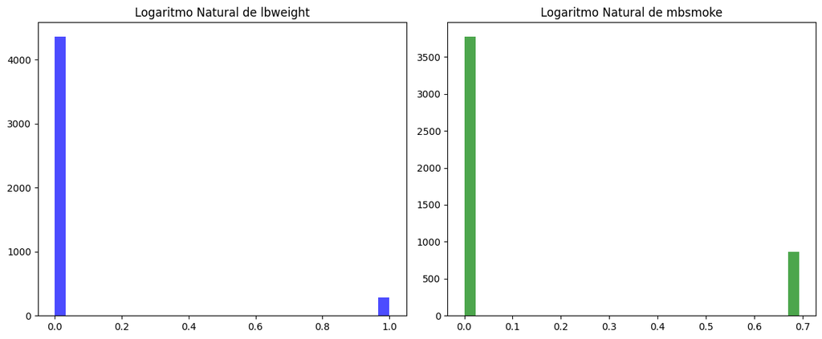

```python
# Agora vamos plotar a distribuição logaritmica (lbweight e log_mdsmoke) e logo em seguida criar um grafico que represente essa distribuição
# Para realizar esse exercicio precisamos importar a biblioteca Matplotib

import matplotlib.pyplot as plt

# Plotar distribuição logarítmica
plt.figure(figsize=(12, 5))

plt.subplot(1, 2, 1)
plt.hist(dadosusuario['lbweight'], bins=30, color='blue', alpha=0.7)
plt.title('Logaritmo Natural de lbweight')

plt.subplot(1, 2, 2)
plt.hist(dadosusuario['log_mbsmoke'], bins=30, color='green', alpha=0.7)
plt.title('Logaritmo Natural de mbsmoke')

plt.tight_layout()
plt.show()
```

```python
# Agora vamos transformar as variáveis bwght em exponencial e também colocar ao quadradro

# Exponencial
dadosusuario['exp_bweight'] = np.exp(dadosusuario['bweight'])

# Ao quadrado

dadosusuario['bweight_squared'] = dadosusuario['bweight'] ** 2
```

- Transformação Exponencial:

Motivação: Estabilização de variância, linearização de relacionamentos exponenciais, interpretação multiplicativa.

- Elevação ao Quadrado:

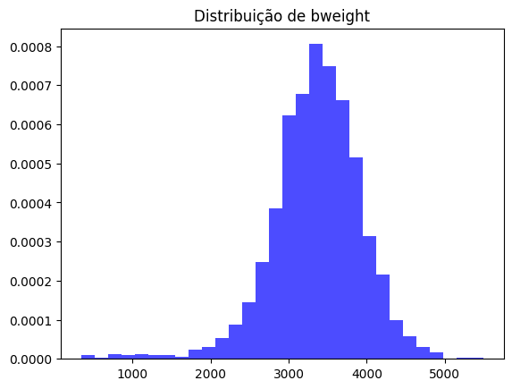

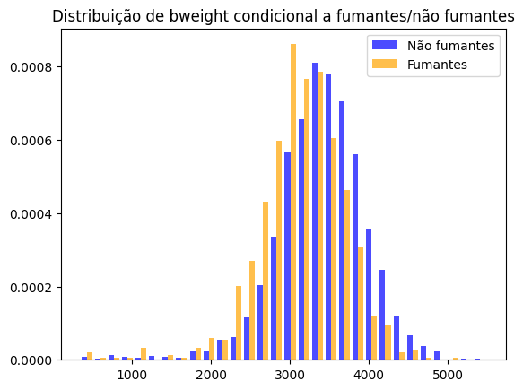

```python
# Vamos plotar a distribuição de variável (bwght)
# E iremos realizar a distribuição condicional (mbsmoke)


import matplotlib.pyplot as plt

# Plotar distribuição
plt.hist(dadosusuario['bweight'], bins=30, color='blue', alpha=0.7, density=True)
plt.title('Distribuição de bweight')
plt.show()

# Distribuição condicional
plt.figure()
plt.hist([dadosusuario[dadosusuario['mbsmoke'] == 0]['bweight'], dadosusuario[dadosusuario['mbsmoke'] == 1]['bweight']],
         bins=30, color=['blue', 'orange'], alpha=0.7, label=['Não fumantes', 'Fumantes'], density=True)
plt.title('Distribuição de bweight condicional a fumantes/não fumantes')
plt.legend()
plt.show()
```

Este histograma condicional compara a distribuição de bweight (peso ao nascer) dos bebes entre se a mãe fumava ou não fumava. Pode indicar se há diferenças notáveis nas distribuições.

```python
# Criando a variável de média condicional
# De bweight para fumantes e não fumantes
# A partir do momento que rodarmos, irá criar uma coluna a mais no banco de dados

dadosusuario['mean_cond_bweight'] = dadosusuario.groupby('mbsmoke')['bweight'].transform('mean')
```

```python
# Diferença de médias de duas variáveis: Teste T
# Usar a biblioteca Scipy

from scipy.stats import ttest_ind

grupo_0 = dadosusuario[dadosusuario['mbsmoke'] == 0]['bweight']
grupo_1 = dadosusuario[dadosusuario['mbsmoke'] == 1]['bweight']

resultado_t_test = ttest_ind(grupo_0, grupo_1, equal_var=False)

print("Estatística t:", resultado_t_test.statistic)
print("Valor p:", resultado_t_test.pvalue)
```

```
Estatística t: 12.970787431389578
Valor p: 2.8343631517784783e-36
```

Em resumo:

Nesse caso, pode-se concluir que há uma diferença estatisticamente significativa entre as médias das duas amostras.

```python
# Gerando tabelas de estatistica descritivas:

desc_stats = dadosusuario.groupby('mbsmoke')['bweight'].describe()
print(desc_stats)
```

```
          count         mean         std    min      25%     50%     75%  \
mbsmoke
0        3778.0  3412.911593  570.687108  340.0  3101.25  3430.0  3771.0
1         864.0  3137.659722  560.893051  397.0  2835.00  3178.5  3487.0

            max
mbsmoke
0        5500.0
1        5018.0
```

Essa tabela fornece um resumo estatístico separado para não fumantes (0) e fumantes (1), incluindo média, desvio padrão, quartis, etc. Facilita a compreensão das características das distribuições condicionais a bweight

```python
# Regressão linear: Rodar regressão sem covariáveis (peso bebê x fumante):
# Para rodar a regressão iremos usar a biblioteca Statsmodels

import statsmodels.api as sm

X = sm.add_constant(dadosusuario['mbsmoke'])
y = dadosusuario['bweight']

# Aplicando o modelo de regressão

model = sm.OLS(y, X).fit()


# Imprimir os resultados
print(model.summary())
```

```
                            OLS Regression Results
==============================================================================
Dep. Variable:                bweight   R-squared:                       0.034
Model:                            OLS   Adj. R-squared:                  0.034
Method:                 Least Squares   F-statistic:                     164.6
Date:                Thu, 16 Nov 2023   Prob (F-statistic):           4.68e-37
Time:                        12:34:09   Log-Likelihood:                -36033.
No. Observations:                4642   AIC:                         7.207e+04
Df Residuals:                    4640   BIC:                         7.208e+04
Df Model:                           1
Covariance Type:            nonrobust
==============================================================================
                 coef    std err          t      P>|t|      [0.025      0.975]
------------------------------------------------------------------------------
const       3412.9116      9.255    368.754      0.000    3394.767    3431.056
mbsmoke     -275.2519     21.453    -12.831      0.000    -317.310    -233.194
==============================================================================
Omnibus:                      739.371   Durbin-Watson:                   2.007
Prob(Omnibus):                  0.000   Jarque-Bera (JB):             2256.717
Skew:                          -0.824   Prob(JB):                         0.00
Kurtosis:                       5.992   Cond. No.                         2.67
==============================================================================

Notes:
[1] Standard Errors assume that the covariance matrix of the errors is correctly specified.
```

**Coeficientes:**

- Constante (Intercepto): 3412.9116 - Representa a média estimada do peso ao nascer para mães não fumantes.
- mbsmoke: -275.2519 - Indica a mudança média no peso ao nascer associada à diferença entre mães fumantes e não fumantes.

**Estatísticas de Ajuste:**

- R-squared: 0.034 - Indica que aproximadamente 3.4% da variabilidade no peso ao nascer é explicada pela variável mbsmoke.
- F-statistic: 164.6 - Teste estatístico para a significância global do modelo.

**Inferências Estatísticas:**

- P>|t| (Valor-p):

Para a constante: 0.000 - Indica que o intercepto é estatisticamente significativo.

Para mbsmoke: 0.000 - Indica que a variável mbsmoke é estatisticamente significativa.

- Intervalo de Confiança (95%):

Para a constante: [3394.767, 3431.056] - Intervalo de confiança para a média do peso ao nascer para mães não fumantes.

Para mbsmoke: [-317.310, -233.194] - Intervalo de confiança para a mudança média associada a mães fumantes.

**Diagnósticos:**

Omnibus: 739.371 - Teste de normalidade dos resíduos.

Prob(Omnibus): 0.000 - Indica que os resíduos não seguem uma distribuição normal.

Jarque-Bera (JB): 2256.717 - Outro teste de normalidade dos resíduos.

Prob(JB): 0.00 - Indica rejeição da hipótese nula de normalidade.

```python
# Iremos rodar uma regressão adicionando outras variáveis

# Supondo que 'mage' e 'medu' sejam as covariáveis
X = sm.add_constant(dadosusuario[['mbsmoke', 'mage', 'medu']])
model = sm.OLS(y, X).fit()

# Imprimir os resultados
print(model.summary())
```

```
                            OLS Regression Results
==============================================================================
Dep. Variable:                bweight   R-squared:                       0.043
Model:                            OLS   Adj. R-squared:                  0.043
Method:                 Least Squares   F-statistic:                     70.14
Date:                Tue, 14 Nov 2023   Prob (F-statistic):           2.34e-44
Time:                        20:44:49   Log-Likelihood:                -36011.
No. Observations:                4642   AIC:                         7.203e+04
Df Residuals:                    4638   BIC:                         7.206e+04
Df Model:                           3
Covariance Type:            nonrobust
==============================================================================
                 coef    std err          t      P>|t|      [0.025      0.975]
------------------------------------------------------------------------------
const       3084.5422     50.879     60.625      0.000    2984.795    3184.290
mbsmoke     -249.5144     21.807    -11.442      0.000    -292.267    -206.761
mage           6.8227      1.622      4.207      0.000       3.643      10.002
medu          11.2490      3.665      3.069      0.002       4.063      18.435
==============================================================================
Omnibus:                      750.499   Durbin-Watson:                   2.011
Prob(Omnibus):                  0.000   Jarque-Bera (JB):             2312.006
Skew:                          -0.833   Prob(JB):                         0.00
Kurtosis:                       6.029   Cond. No.                         185.
==============================================================================

Notes:
[1] Standard Errors assume that the covariance matrix of the errors is correctly specified.
```

**Explicando a Regressão:**

- R-squared e Adj. R-squared:

Interpretação: A porcentagem de variabilidade em bweight explicada pelo modelo é baixa (R-squared = 0.043), indicando que o modelo não captura a maior parte da variação na variável dependente.

- F-statistic e Prob (F-statistic):

Interpretação: p-valor baixo (Prob (F-statistic) < 0.05).

- Coeficientes e P>|t|:

Interpretação: A variável mbsmoke é estatisticamente significativa (p < 0.05), indicando uma associação significativa com bweight. As variáveis mage e medu também são estatisticamente significativas.

- Estatísticas sobre os resíduos:

- Cond. No.:

- Notas:

```python
# Criando uma Tabela com os resultados da ultima regressão.

results_table = pd.DataFrame({
    'Variable': ['Intercept'] + list(X.columns[1:]),
    'Coefficient': model.params.values,
    'Std. Error': model.bse.values,
    't-value': model.tvalues.values,
    'p-value': model.pvalues.values
})

print(results_table)
```

```
    Variable  Coefficient  Std. Error    t-value       p-value
0  Intercept  3084.542194   50.879320  60.624674  0.000000e+00
1    mbsmoke  -249.514395   21.807494 -11.441681  6.498605e-30
2       mage     6.822737    1.621769   4.206972  2.637030e-05
3       medu    11.249044    3.665284   3.069078  2.159612e-03
```

A tabela resume os coeficientes, erros padrão, estatísticas t e valores p para cada variável no modelo. Ajuda a avaliar a significância estatística das relações entre as variáveis.